# The Fed: Inflation and Employment

Load Packages

```r
library(jsonlite)
library(tidyverse)
library(httr)
library(ggplot2)
library(patchwork)
```

```r
url <- "https://api.bls.gov/publicAPI/v2/timeseries/data/"

payload <- toJSON(list(
  seriesid = list("CUSR0000SA0", "LNS14000000"),
  startyear = "2000",
  endyear = "2026",
  registrationkey = Sys.getenv("BLS_KEY")
), auto_unbox = TRUE)

response <- POST(
  url,
  body = payload,
  add_headers("Content-Type" = "application/json")
)

parsed <- content(response, as = "text", encoding = "UTF-8") |> fromJSON(simplifyVector = FALSE)

cpi1 <- parsed$Results$series[[1]]$data
ue1 <- parsed$Results$series[[2]]$data
```

Make an API call to the Department of Labor for the CPI and Unemployment rate for 2020-2026

```r
url <- "https://api.bls.gov/publicAPI/v2/timeseries/data/"

payload1 <- toJSON(list(
  seriesid = list("CUSR0000SA0", "LNS14000000"),
  startyear = "2020",
  endyear = "2026",
  registrationkey = Sys.getenv("BLS_KEY")
), auto_unbox = TRUE)

response1 <- POST(
  url,
  body = payload1,
  add_headers("Content-Type" = "application/json")
)

parsed1 <- content(response1, as = "text", encoding = "UTF-8") |> fromJSON(simplifyVector = FALSE)

cpi2 <- parsed1$Results$series[[1]]$data
ue2 <- parsed1$Results$series[[2]]$data
```

Build dataframes of the API calls

```r
cpi <- bind_rows(cpi1, cpi2) |> arrange(year, period) |> mutate(
  year = as.integer(year),
  cpi = as.numeric(value)
) |> select(-footnotes,-latest, -value)

ue <- bind_rows(ue1, ue2) |> arrange(year, period) |> mutate(
  year = as.integer(year),
  unemployment_rate = as.numeric(value)
) |> select(-footnotes,-latest, -value)

cpi_ue <- left_join(cpi, ue, by = c("year","period","periodName"))
```

Make an API call to the Fed for the Funds Rate

```r
fed_url <- "https://api.stlouisfed.org/fred/series/observations"

payload2 <- GET(
  fed_url,
  query = list(
    series_id = "FEDFUNDS",
    api_key = Sys.getenv("FED_KEY"),
    file_type = "json",
    observation_start = "2000-01-01",
    observation_end = "2026-02-01"
  )
)

fed_data <- content(payload2, as="text") |> fromJSON()

fed_funds <- fed_data$observations |> select(date:value) |> mutate(
  date = as.Date(date),
  fed_rate = value) |>
  select(-value) |>
  mutate(
    year = year(date),
    period = sprintf("M%02d", month(date))
  ) |>
  select(-date) |>
  relocate(c(year, period, fed_rate))
```

[output not shown]

Inspect the dataframe

```r
fed_funds
```

|  | year | period | fed_rate |
| --- | --- | --- | --- |
| 1 | 2000 | M01 | 5.45 |
| 2 | 2000 | M02 | 5.73 |
| 3 | 2000 | M03 | 5.85 |
| 4 | 2000 | M04 | 6.02 |
| 5 | 2000 | M05 | 6.27 |
| 6 | 2000 | M06 | 6.53 |
| 7 | 2000 | M07 | 6.54 |
| 8 | 2000 | M08 | 6.50 |
| 9 | 2000 | M09 | 6.52 |
| 10 | 2000 | M10 | 6.51 |

[output cut: 303 more lines]

Join the dataframes from the API calls

```r
df_all <- left_join(cpi_ue,fed_funds, by=c("year", "period"))
```

Clean and adjust the data to create references

```r
df_all <- df_all |> mutate(
  month_no = as.numeric((str_extract_all(period,"\\d+")))) |>
  mutate(
    year_month = ymd(as.Date(str_glue("{year}-{month_no}-01"))),
    fed_rate = as.numeric(fed_rate),
    inflation_mom = 100 * (log(cpi) - log(lag(cpi))),
    inflation_yoy = 100 * (log(cpi) - log(lag(cpi, 12))),
    unemp_change = unemployment_rate - lag(unemployment_rate),
    fed_lag = lag(fed_rate)
  )
```

Inspect the dataframe

```r
head(df_all)
```

| year | period | periodName | cpi | unemployment_rate | fed_rate | month_no | year_month | inflation_mom | inflation_yoy | unemp_change | fed_lag |
| --- | --- | --- | --- | --- | --- | --- | --- | --- | --- | --- | --- |
| 2000 | M01 | January | 169.3 | 4.0 | 5.45 | 1 | 2000-01-01 | NA | NA | NA | NA |
| 2000 | M02 | February | 170.0 | 4.1 | 5.73 | 2 | 2000-02-01 | 0.41261479 | NA | 0.1 | 5.45 |
| 2000 | M03 | March | 171.0 | 4.0 | 5.85 | 3 | 2000-03-01 | 0.58651195 | NA | -0.1 | 5.73 |
| 2000 | M04 | April | 170.9 | 3.8 | 6.02 | 4 | 2000-04-01 | -0.05849664 | NA | -0.2 | 5.85 |
| 2000 | M05 | May | 171.2 | 4.0 | 6.27 | 5 | 2000-05-01 | 0.17538736 | NA | 0.2 | 6.02 |
| 2000 | M06 | June | 172.2 | 4.0 | 6.53 | 6 | 2000-06-01 | 0.58241283 | NA | 0.0 | 6.27 |

Explore some graphs

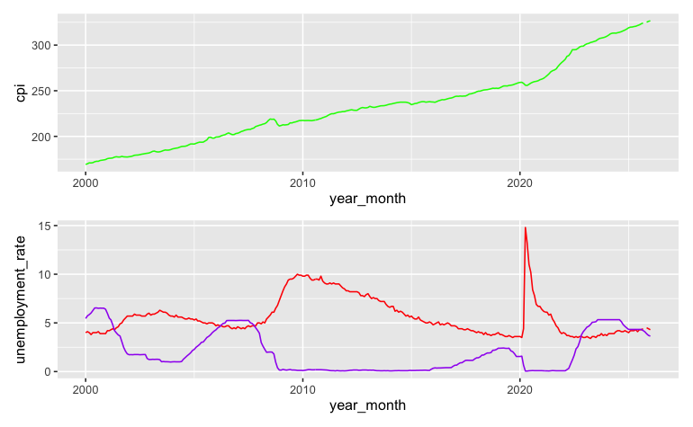

```r
g1 <- ggplot(data=df_all, aes(x=year_month)) +
  geom_line(aes(y=cpi), color = "green")

g2 <- ggplot(data=df_all, aes(x=year_month)) +
  geom_line(aes(y=unemployment_rate), color = "red") +
  geom_line(aes(y=fed_rate), color = "purple")

g1 / g2
```

Continue to explore visualization

[figure not shown]

Prepare a Linear model of the fed rate, inflation rate, and unemployment correlation

```r
summary(model)
```

```
Call:
lm(formula = fed_rate ~ fed_lag + inflation_yoy + unemployment_rate,
    data = df_all)

Residuals:
     Min       1Q   Median       3Q      Max
-0.94621 -0.02496  0.01711  0.07434  0.58370

Coefficients:
                   Estimate Std. Error t value Pr(>|t|)
(Intercept)        0.073951   0.052747   1.402  0.16197
fed_lag            0.969513   0.006447 150.371  < 2e-16 ***
inflation_yoy      0.028852   0.006500   4.439 1.28e-05 ***
unemployment_rate -0.017295   0.006618  -2.613  0.00942 **
---
Signif. codes:  0 ‘***’ 0.001 ‘**’ 0.01 ‘*’ 0.05 ‘.’ 0.1 ‘ ’ 1

Residual standard error: 0.172 on 296 degrees of freedom
  (13 observations deleted due to missingness)
Multiple R-squared:  0.9917,    Adjusted R-squared:  0.9916
F-statistic: 1.181e+04 on 3 and 296 DF,  p-value: < 2.2e-16
```

```r
cor(df_all$inflation_yoy, lag(df_all$fed_rate, 12), use="complete.obs")
```

```
[1] 0.02374964
```

Prepare a chart of the main data

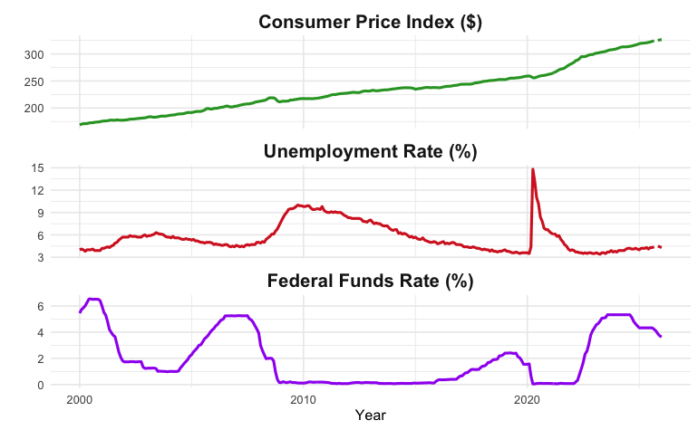

```r
df_long <- df_all |>
  select(year_month, cpi, unemployment_rate, fed_rate) |>
  pivot_longer(
    cols = -year_month,
    names_to = "series",
    values_to = "value"
  )

df_long$series <- factor(
  df_long$series,
  levels = c("cpi", "unemployment_rate", "fed_rate")
)

ggplot(df_long, aes(x = year_month, y = value, color = series)) +
  geom_line(size = 1) +
  facet_wrap(
    ~series,
    ncol = 1,
    scales = "free_y",
    labeller = labeller(
      series = c(
        cpi     = "Consumer Price Index ($)",
        unemployment_rate = "Unemployment Rate (%)",
        fed_rate          = "Federal Funds Rate (%)"
      )
    )
  ) +
  scale_color_manual(
    values = c(
      cpi     = "#2CA02C",
      unemployment_rate = "#D62728",
      fed_rate          = "purple"
    )
  ) +
  theme_minimal() +
  theme(
    legend.position = "none",
    strip.text = element_text(size = 14, face = "bold")
  ) +
  labs(
    x = "Year",
    y = ""
  )
```

Calculate the average inflation rate

```r
inflation_avg <- df_all |> summarise(avg_inflation_yoy = mean(inflation_yoy, na.rm = TRUE))

inflation_avg_yoy <- df_all |> group_by(year) |> summarise(avg_inflation_yoy = mean(inflation_yoy, na.rm =TRUE))

inflation_avg
```

| avg_inflation_yoy |
| --- |
| 2.504649 |

Create an average inflation chart by year

```r
inflation_avg_yoy <- inflation_avg_yoy |> mutate(
  target_inflation_yoy = 2.00
)

inflation_avg_yoy
```

| year | avg_inflation_yoy | target_inflation_yoy |
| --- | --- | --- |
| 2000 | NaN | 2 |
| 2001 | 2.7813316 | 2 |
| 2002 | 1.5814193 | 2 |
| 2003 | 2.2732968 | 2 |
| 2004 | 2.6294829 | 2 |
| 2005 | 3.3063179 | 2 |
| 2006 | 3.1772058 | 2 |
| 2007 | 2.8263423 | 2 |
| 2008 | 3.7424987 | 2 |
| 2009 | -0.3167966 | 2 |

[output cut: 17 more lines]

Explore a possible plot

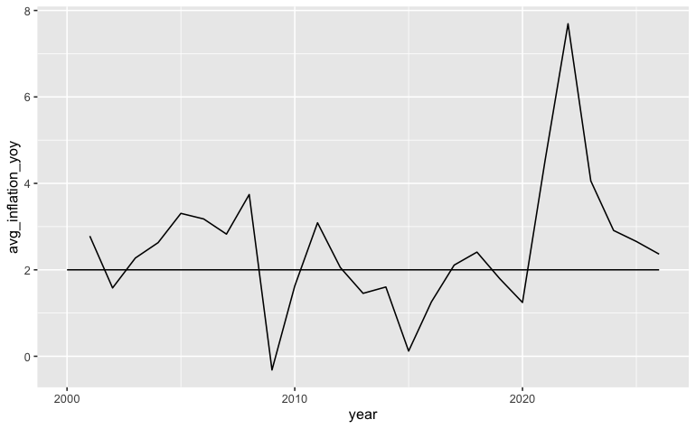

```r
ggplot(inflation_avg_yoy, aes(x=year)) +
  geom_line(aes(y=avg_inflation_yoy)) +
  geom_line(aes(y=target_inflation_yoy))
```

Prepare a dataframe for analysis

```r
constant2pct_rate <- list(1.00)
year <- list("2000-01-01")

rate_mult <- 1.02^25

for (n in 1:25) {
  rate <- 1.02^n
  constant2pct_rate[[length(constant2pct_rate)+1]] <- rate
  thisyear <- paste0((2000+n),"-","01","-","01")
  year[[length(year)+1]] <- thisyear
}


df <- data_frame(year_month = unlist(year), rate_change = unlist(constant2pct_rate)) |> mutate(
  year_month = as.Date(year_month)
)

df <- left_join(df, df_all, by = "year_month")

df <- df |>  mutate(
  cpiplus_2pct = cpi[1] * rate_change,
  overprevyr2pct = lag(cpi) * 1.02,
  pct_yoy = (lead(cpi)/cpi-1)*100
)
```

Calculate the average inflation rate

```r
avg_inflation <- df |> summarise(mean(inflation_yoy, na.rm = TRUE))
```

Calculate the inflation count

```r
inflation_count <- df |>  summarise(above_target = sum(inflation_yoy >2, na.rm = TRUE))
```

Explore the plot with a linechart

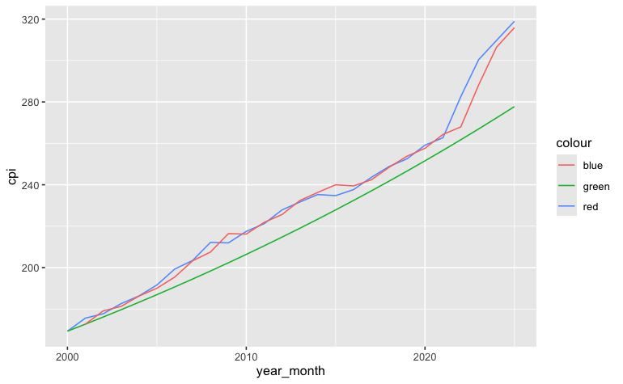

```r
ggplot(df, aes(x=year_month)) +
  geom_line(aes(y=cpi, color = "red")) +
  geom_line(aes(y=cpiplus_2pct, color = "green")) +
  geom_line(aes(y=overprevyr2pct, color = "blue"))
```

Prepare the dataframe for more analysis

```r
df <- df |> mutate(
  deviation = pct_yoy - 2,
  cum_dev = cumsum(deviation),
  unemployment_change = unemployment_rate - lag(unemployment_rate, default = 0),
  cum_unempl_change = cumsum(unemployment_change)
)
```

Calculate average unemployment

```r
avg_unemployment <- df |> summarise(mean(unemployment_rate, na.rm = TRUE))
```

Create a chart for inflation deviation

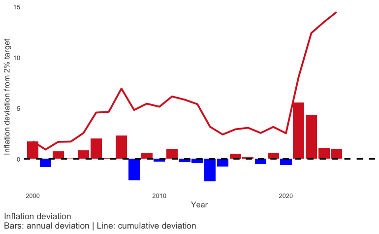

```r
ggplot(df, aes(x = year_month)) +
  geom_col(aes(y = deviation, fill = deviation > 0)) +
  geom_line(aes(y = cum_dev), color = "#D62728", size = 1.2) +
  geom_hline(yintercept = 0, linetype = "dashed", size = 1) +
  scale_fill_manual(
    values = c("TRUE" = "#D62728",
               "FALSE" = "blue"),
    guide = "none"
  ) +
  theme_minimal() +
  labs(
    x = "Year",
    y = "Inflation deviation from 2% target",
    caption = "Inflation deviation\nBars: annual deviation | Line: cumulative deviation",
    title = NULL
  ) +
  theme(
    text = element_text(color = "gray30"),
    panel.grid.major = element_blank(),
    panel.grid.minor = element_blank(),
    plot.caption = element_text(
      size = 12,
      hjust = 0
    ),
    plot.caption.position = "plot"
  ) +
  scale_x_date(expand = expansion(mult = c(0.01, 0.08)))
```

Create a chart for unempployment deviation

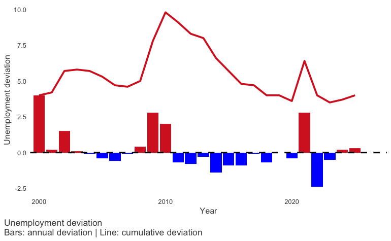

```r
ggplot(df, aes(x = year_month)) +
  geom_col(aes(y = unemployment_change, fill = unemployment_change > 0)) +
  geom_line(aes(y = cum_unempl_change), color = "#D62728", size = 1.2) +
  geom_hline(yintercept = 0, linetype = "dashed", size = 1) +
  scale_fill_manual(
    values = c("TRUE" = "#D62728",
               "FALSE" = "blue"),
    guide = "none"
  ) +
  theme_minimal() +
  labs(
    x = "Year",
    y = "Unemployment deviation",
    caption = "Unemployment deviation\nBars: annual deviation | Line: cumulative deviation",
    title = NULL
  ) +
  theme(
    text = element_text(color = "gray30"),
    panel.grid.major = element_blank(),
    panel.grid.minor = element_blank(),
    plot.caption = element_text(
      size = 12,
      hjust = 0
    ),
    plot.caption.position = "plot"
  ) +
  scale_x_date(expand = expansion(mult = c(0.01, 0.08)))
```

Chart the main data

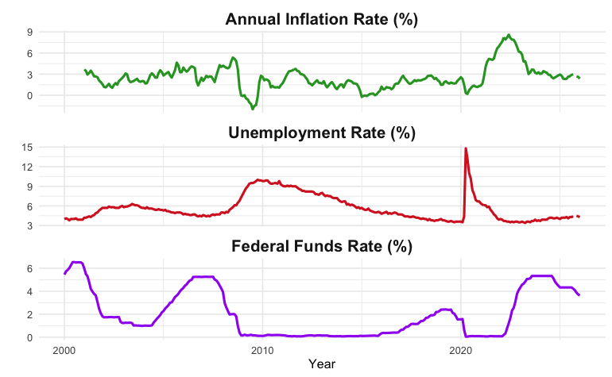

```r
df_long <- df_all |>
  select(year_month, inflation_yoy, unemployment_rate, fed_rate) |>
  pivot_longer(
    cols = -year_month,
    names_to = "series",
    values_to = "value"
  )

df_long$series <- factor(
  df_long$series,
  levels = c("inflation_yoy", "unemployment_rate", "fed_rate")
)

ggplot(df_long, aes(x = year_month, y = value, color = series)) +
  geom_line(size = 1) +
  facet_wrap(
    ~series,
    ncol = 1,
    scales = "free_y",
    labeller = labeller(
      series = c(
        inflation_yoy = "Annual Inflation Rate (%)",
        unemployment_rate = "Unemployment Rate (%)",
        fed_rate          = "Federal Funds Rate (%)"
      )
    )
  ) +
  scale_color_manual(
    values = c(
      inflation_yoy     = "#2CA02C",
      unemployment_rate = "#D62728",
      fed_rate          = "purple"
    )
  ) +
  theme_minimal() +
  theme(
    legend.position = "none",
    strip.text = element_text(size = 14, face = "bold")
  ) +
  labs(
    x = "Year",
    y = ""
  )
```

Prepare subsets of data

```r
df_2008 <- df_all |> filter(year >= 2007 & year <= 2012) |> select(year_month, inflation_yoy, unemployment_rate, fed_rate) |>
  pivot_longer(
    cols = -year_month,
    names_to = "series",
    values_to = "value"
  )

df_2020 <- df_all |> filter(year >= 2019 & year <= 2025) |> select(year_month, inflation_yoy, unemployment_rate, fed_rate) |>
  pivot_longer(
    cols = -year_month,
    names_to = "series",
    values_to = "value"
  )
```

Prepare a chart to highlight 2008 and 2020

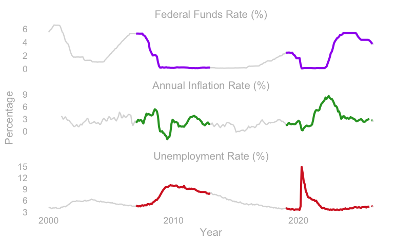

```r
df_long <- df_all |>
  select(year_month, inflation_yoy, unemployment_rate, fed_rate) |>
  pivot_longer(
    cols = -year_month,
    names_to = "series",
    values_to = "value"
  )

df_long$series <- factor(
  df_long$series,
  levels = c("inflation_yoy", "unemployment_rate", "fed_rate")
)


ggplot(df_long, aes(x = year_month, y = value)) +

  geom_line(aes(group = series), color = "gray70", size = 0.8, alpha = 0.5) +


  geom_line(
    data = df_2008,
    aes(x = year_month, y = value, color = series),
    size = 1.3
  ) +


  geom_line(
    data = df_2020,
    aes(x = year_month, y = value, color = series),
    size = 1.3
  ) +


  facet_wrap(
    ~series,
    ncol = 1,
    scales = "free_y",
    labeller = labeller(
      series = c(
        inflation_yoy = "Annual Inflation Rate (%)",
        unemployment_rate = "Unemployment Rate (%)",
        fed_rate = "Federal Funds Rate (%)"
      )
    )
  ) +

  # Colors for highlights
  scale_color_manual(
    values = c(
      inflation_yoy     = "#2CA02C",
      unemployment_rate = "#D62728",
      fed_rate          = "purple"
    )
  ) +

  theme_minimal(base_size = 14) +
  theme(
    legend.position = "none", # or "none" if you prefer no legend
    strip.text = element_text(size = 14, color = "gray70"),
    axis.title = element_text(color = "gray70", size = 14),
    axis.text = element_text(color = "gray70", size = 12),
    panel.grid = element_blank()
  ) +

  labs(
    x = "Year",
    y = "Percentage",
    color = "gray70"
  )
```

Explore a possible chart

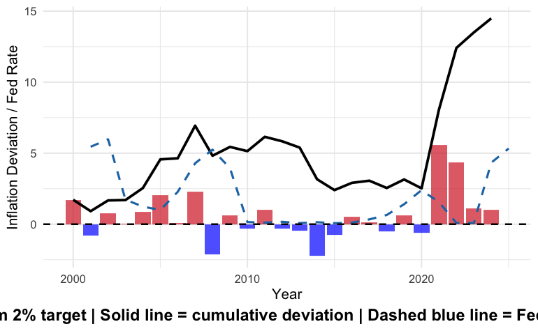

```r
df <- df %>%
  arrange(year_month) %>%
  mutate(fed_rate_lag12 = lag(fed_rate, 1))  # 12-month lag

ggplot(df, aes(x = year_month)) +

  # Bars: annual inflation deviation
  geom_col(aes(y = deviation, fill = deviation > 0), alpha = 0.7) +

  # Cumulative deviation line
  geom_line(aes(y = cum_dev), color = "black", size = 1.2) +

  # Lagged Fed rate line (scaled if necessary)
  geom_line(aes(y = fed_rate_lag12), color = "#1F77B4", size = 1, linetype = "dashed") +

  # Zero line
  geom_hline(yintercept = 0, linetype = "dashed", size = 0.8) +

  # Color scale for bars
  scale_fill_manual(values = c("TRUE" = "#D62728", "FALSE" = "blue"), guide = "none") +

  # Minimal theme
  theme_minimal(base_size = 14) +
  theme(
    plot.caption = element_text(size = 16, face = "bold", hjust = 0.5),
    plot.caption.position = "plot"
  ) +

  # Labels
  labs(
    x = "Year",
    y = "Inflation Deviation / Fed Rate",
    caption = "Bars = deviation from 2% target | Solid line = cumulative deviation | Dashed blue line = Fed rate (12-month lag)"
  )
```

Subset the subset

```r
df_2008_slice <- df_2008 |> filter(year_month >= "2008-01-01" & year_month <= "2010-01-01")
```

[figure not shown]

```r
df_2020_slice <- df_2020 |> filter(year_month >= "2020-01-01" & year_month <= "2025-01-01")
```

[figure not shown]

[figure not shown]